# PASIAS Ch 6 - One-Sample Inference

Mohammad Amr Khan

## Packages

```r
library(tidyverse)
```

## 6.1 Hunter-gathers in Australia

### Brief

A hunter-gatherer society is one where people get their food by hunting, fishing or foraging rather than by agriculture or by raising animals. Such societies tend to move from place to place. Anthropologists have studied hunter-gatherer societies in forest ecosystems across the world. The average population density of these societies is 7.38 people per 100 km. Hunter-gatherer societies on different continents might have different population densities, possibly because of large-scale ecological constraints (such as resource availability), or because of other factors, possibly social and/or historic, determining population density.

### Data

The data is available at *http://www.utsc.utoronto.ca/~butler/c32/hg.txt*

Some hunter-gatherer societies in Australia were studied, and the population density per 100 km recorded for each.

The data set looks to be space delimited so we can use read_delim

```r
hunter_url <- "http://www.utsc.utoronto.ca/~butler/c32/hg.txt"
hunter_data <- read_delim(hunter_url, " ")
```

```r
hunter_data
```

| name | density |
| --- | --- |
| jeidji | 17.00 |
| kuku | 50.00 |
| mamu | 45.00 |
| ngatjan | 59.80 |
| undanbi | 21.74 |
| jinibarra | 16.00 |
| ualaria | 9.00 |
| barkindji | 15.43 |
| wongaibon | 5.12 |
| jaralde | 40.00 |

[output cut: 3 more lines]

The data set contains 13 rows (13 societies) and their associated population denisty

#### Question of Interest

The question of interest is whether these Australian hunter-gatherer societies are like the rest of the world in terms of mean population density.

*Null Hypothesis* The mean population density is 7.38 *Alternative Hypothesis* The mean population is not 7.38

Since this is a one sample data set we can use the t test to test our hypothesis.

```r
t.test(hunter_data$density, mu=7.38)
```

```
    One Sample t-test

data:  hunter_data$density
t = 3.8627, df = 12, p-value = 0.002257
alternative hypothesis: true mean is not equal to 7.38
95 percent confidence interval:
 15.59244 36.84449
sample estimates:
mean of x
 26.21846
```

The p-value is smaller than *0.05* so we reject the null hypothesis. That is to say that the societies do not have a mean population denity is 7.38

**The Assumption required to use a t test is that the data is normally distributed**

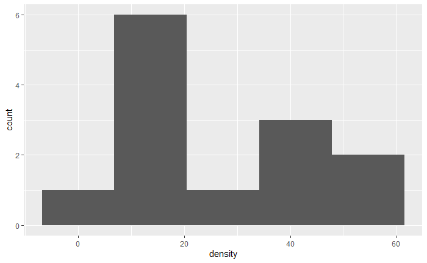

```r
ggplot(hunter_data, aes(x=density)) + geom_histogram(bins = 5)
```

The data its self is not normal. we can see this from the histogram.

We can see if the sampling distribution of the sample means is normal.

```r
rerun(1000, sample(hunter_data$density, replace = TRUE)) %>%
  map_dbl(~mean(.)) %>%
  enframe() -> d
d
```

| name | value |
| --- | --- |
| 1 | 31.78769 |
| 2 | 32.14692 |
| 3 | 26.18538 |
| 4 | 28.82462 |
| 5 | 26.40000 |
| 6 | 27.38308 |
| 7 | 26.53923 |
| 8 | 24.71769 |
| 9 | 19.63154 |
| 10 | 20.59692 |

[output cut: 990 more lines]

we now have the mean for 1000 samples of the data.

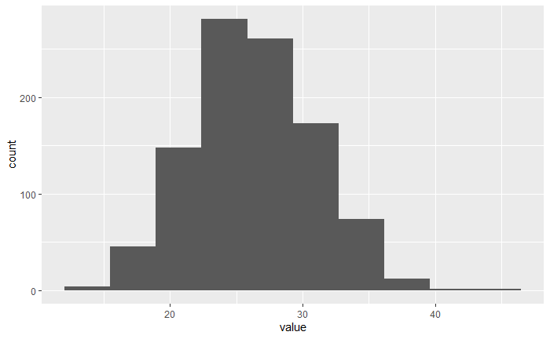

```r
ggplot(d, aes(x=value)) + geom_histogram(bins = 10)
```

This shows that the sampling means do looks to be normally distributed we can use the t test.

## 6.2 Buses to Boulders

### Brief

A bus line operates a route from Denver to Boulder (these places are in Colorado). The schedule says that the journey time should be 60 minutes. 11 randomly chosen journey times were recorded, and these are in the file link, with journey times shown in minutes.

The data set is a single column

```r
bus_url <- "http://www.utsc.utoronto.ca/~butler/d29/buses.txt"
bus_data <- read_delim(bus_url, " ")
```

The single column has been read

```r
bus_data
```

| minutes |
| --- |
| 58 |
| 61 |
| 69 |
| 62 |
| 81 |
| 54 |
| 72 |
| 71 |
| 53 |
| 54 |

[output cut: 1 more lines]

We get the 11 rows of data.

*Null Hypothesis* the mean trip time is 60 minutes *Alternative Hypothesis* the mean trip is not 60 minutes

```r
t.test(bus_data$minutes, mu=60)
```

```
    One Sample t-test

data:  bus_data$minutes
t = 1.382, df = 10, p-value = 0.1971
alternative hypothesis: true mean is not equal to 60
95 percent confidence interval:
 57.71775 69.73680
sample estimates:
mean of x
 63.72727
```

The p-value is 0.1971 which is not less than 0.05 so we cannot reject the null hypothesis. That is to say we cannot say that the mean trip time is not 60 minutes.

To get the 95% CI

```r
t.test(bus_data$minutes, conf.level = 0.95)
```

```
    One Sample t-test

data:  bus_data$minutes
t = 23.628, df = 10, p-value = 4.183e-10
alternative hypothesis: true mean is not equal to 0
95 percent confidence interval:
 57.71775 69.73680
sample estimates:
mean of x
 63.72727
```

The 95% CI interval for the mean is 57.7 to 69.74. 60 minutes is within this interval.

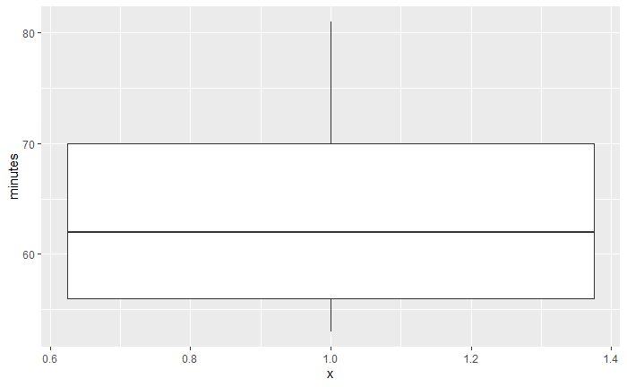

```r
ggplot(bus_data, aes(x=1, y=minutes)) + geom_boxplot()
```

The boxplot shows the top whisker is longer than the bottom one, which shows that the data is right skewed.

The may show that the data is not normally distributed, we can use a histogram to check

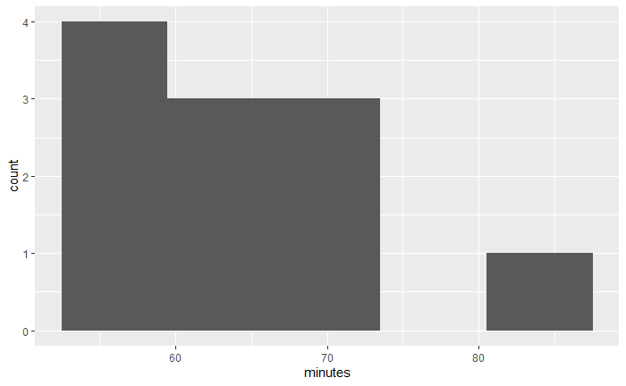

```r
ggplot(bus_data, aes(x=minutes)) + geom_histogram(bins = 5)
```

The data is right skewed and does not appeared to be normally distributed. Since the t test assumes normality, we need to check the sampling distribution of the sampling mean to determine if the t test is a good test to use.

```r
bus <- rerun(1000, sample(bus_data$minutes, replace = TRUE)) %>%
  map_dbl(~mean(.)) %>%
  enframe()

bus
```

| name | value |
| --- | --- |
| 1 | 65.90909 |
| 2 | 61.63636 |
| 3 | 63.81818 |
| 4 | 69.90909 |
| 5 | 64.27273 |
| 6 | 65.18182 |
| 7 | 62.72727 |
| 8 | 61.54545 |
| 9 | 63.63636 |
| 10 | 61.09091 |

[output cut: 990 more lines]

The sample means for 1000 samples are stored in the data frame called bus.

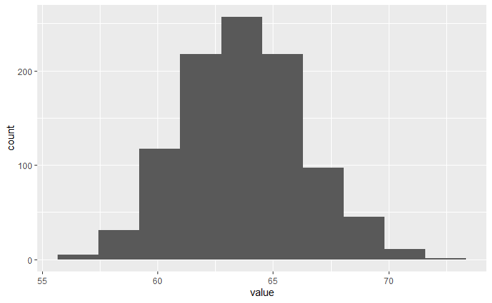

```r
ggplot(bus, aes(value)) + geom_histogram(bins=10)
```

The data is normally distributed so the t test is a good test.

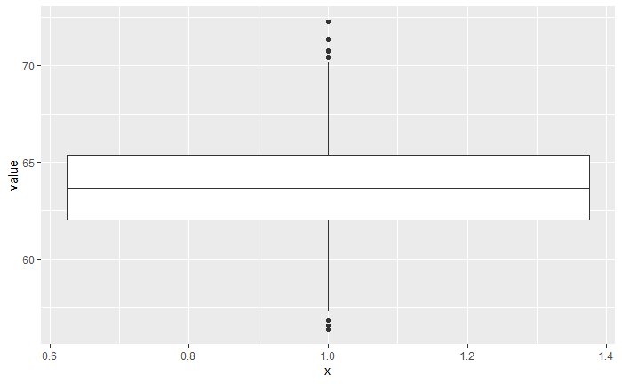

```r
ggplot(bus, aes(x=1, y=value)) + geom_boxplot()
```

The whiskers look to be the same size whith a few outliers. Shows symmetric data.

### Length of Gestation in North Carolina

### Brief

Data is available at *http://www.utsc.utoronto.ca/~butler/c32/ncbirths.csv*

It is a csv file.

```r
birth_url <- "http://www.utsc.utoronto.ca/~butler/c32/ncbirths.csv"
birth_data <- read_csv(birth_url)
```

Let’s see if the birth weight are normally distributed

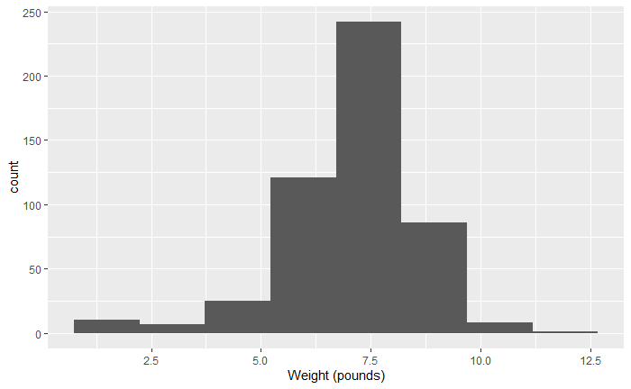

```r
ggplot(birth_data, aes(x=`Weight (pounds)`)) + geom_histogram(bins = 8)
```

The does looks normal with a skew to the left. This should be expected since the births were randomly selected

To get the 95% CI we can run a t test.

```r
t.test(birth_data$`Weight (pounds)`)
```

```
    One Sample t-test

data:  birth_data$`Weight (pounds)`
t = 104.94, df = 499, p-value < 2.2e-16
alternative hypothesis: true mean is not equal to 0
95 percent confidence interval:
 6.936407 7.201093
sample estimates:
mean of x
  7.06875
```

The 95% CI for the mean birth weight is 6.94 lbs to 7.20 lbs.

### hypothesis Tests

#### Brief

Birth weights of babies born in the United States have a mean of 7.3 pounds. Is there any evidence that babies born in North Carolina are less heavy on average? State appropriate hypotheses, do your test, obtain a P-value and state your conclusion, in terms of the original data.

**We need to run a one-sided hypothesis test** *Before we do that, let’s check run a hypothesis tests to see if the birth weight has a mean of 7.3 pounds.*

Here are our hypothesis: Null: mean birth weight is 7.3 pounds Alternative: mean birth weight is not 7.3 pounds

```r
t.test(birth_data$`Weight (pounds)`, mu=7.3)
```

```
    One Sample t-test

data:  birth_data$`Weight (pounds)`
t = -3.4331, df = 499, p-value = 0.0006464
alternative hypothesis: true mean is not equal to 7.3
95 percent confidence interval:
 6.936407 7.201093
sample estimates:
mean of x
  7.06875
```

The p-value is 0.0006 which is smaller than 0.05 so we reject the null hypothesis. This means that the birth weights do not have a mean of 7.3 pounds.

Let check if the NC babies have a lower mean weight than the US mean. *This is one sided test* Null: mean birth weight is 7.3 pounds Alternative: mean birth weight < 7.3 pounds

Since the value we are looking at is the birth weight, we need to use the command $alternative = “less” since we are looking to see if the weight are lower.

```r
t.test(birth_data$`Weight (pounds)`, mu=7.3, alternative = "less")
```

```
    One Sample t-test

data:  birth_data$`Weight (pounds)`
t = -3.4331, df = 499, p-value = 0.0003232
alternative hypothesis: true mean is less than 7.3
95 percent confidence interval:
     -Inf 7.179752
sample estimates:
mean of x
  7.06875
```

The t-test works well here because of the large data set.

## 6.4 Inferring Ice Break-up in Nenana

### Brief

Nenana, Alaska, is about 50 miles west of Fairbanks. Every spring, there is a contest in Nenana. A wooden tripod is placed on the frozen river, and people try to guess the exact minute when the ice melts enough for the tripod to fall through the ice. The contest started in 1917 as an amusement for railway workers, and has taken place every year since. Now, hundreds of thousands of people enter their guesses on the Internet and the prize for the winner can be as much as $300,000.

Because so much money is at stake, and because the exact same tripod is placed at the exact same spot on the ice every year, the data are consistent and accurate.

```r
nenana_url <- "http://www.utsc.utoronto.ca/~butler/c32/nenana.txt"
nenana_data <- read_tsv(nenana_url)
```

```r
nenana_data
```

| Year | JulianDate | Date&Time |
| --- | --- | --- |
| 1917 | 120.4795 | April 30 at 11:30 AM |
| 1918 | 131.3983 | May 11 at 9:33 AM |
| 1919 | 123.6066 | May 3 at 2:33 PM |
| 1920 | 132.4490 | May 11 at 10:46 AM |
| 1921 | 131.2795 | May 11 at 6:42 AM |
| 1922 | 132.5559 | May 12 at 1:20 PM |
| 1923 | 129.0837 | May 9 at 2:00 AM |
| 1924 | 132.6323 | May 11 at 3:10 PM |
| 1925 | 127.7726 | May 7 at 6:32 PM |
| 1926 | 116.6691 | April 26 at 4:03 PM |

[output cut: 77 more lines]

Getting a 90% CI on the mean Julian date

```r
t.test(nenana_data$JulianDate, conf.level = 0.90)
```

```
    One Sample t-test

data:  nenana_data$JulianDate
t = 197.41, df = 86, p-value < 2.2e-16
alternative hypothesis: true mean is not equal to 0
90 percent confidence interval:
 124.4869 126.6018
sample estimates:
mean of x
 125.5443
```

The 90% confidence interval of the mean JulianDate is 124.5 to 126.6

The t test assumed normality

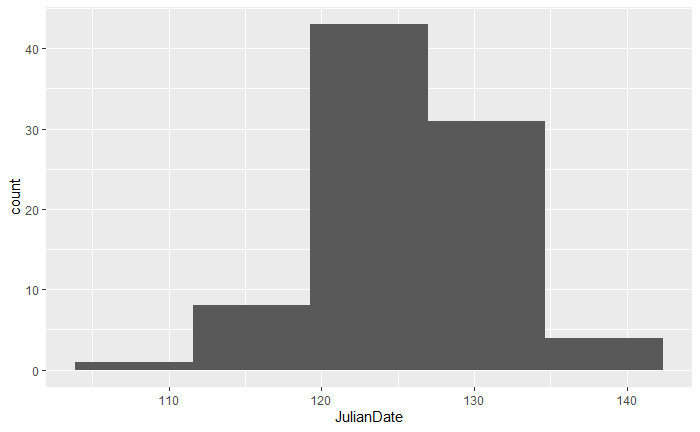

```r
ggplot(nenana_data, aes(x=JulianDate)) + geom_histogram(bins = 5)
```

Looks to be normally distrbuted with slight left skew.

*Null Hypothesis* the after JulianDate for the stake falling is 130 *Alternative Hypothesis* the mean is not 130

Two-sided test

```r
t.test(nenana_data$JulianDate, mu=130)
```

```
    One Sample t-test

data:  nenana_data$JulianDate
t = -7.0063, df = 86, p-value = 5.15e-10
alternative hypothesis: true mean is not equal to 130
95 percent confidence interval:
 124.2801 126.8085
sample estimates:
mean of x
 125.5443
```

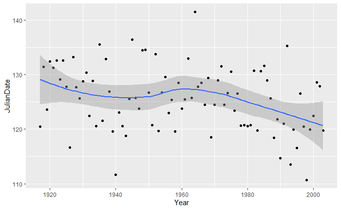

```r
ggplot(nenana_data, aes(x = Year, y = JulianDate)) + geom_point() + geom_smooth()
```